# 22 Survival Analysis with Causal Inference

```julia
using DataFrames
using Distributions
using GLM
using Statistics
using Random
using LinearAlgebra
using Printf
using CairoMakie
CairoMakie.activate!(type = "png")
using CSV
```

When the outcome is time-to-event, such as death, readmission, job exit, or machine failure, ordinary regression is not enough. Some observations are censored. We know the event had not happened by the end of follow-up, but we do not know the event time.

This Julia chapter implements Kaplan-Meier curves, IPW-adjusted survival curves, and RMST differences. For Cox models and doubly robust survival estimators, R’s `survival` and `riskRegression` packages are still the more practical tools; see the [R companion chapter](https://xiangao.github.io/causal_econometrics_guide/survival-causal.html).

## 22.1 The censoring problem

We observe $\min(T_i, C_i)$ and $\delta_i = \mathbb{1}\{T_i \le C_i\}$, where $T_i$ is the event time and $C_i$ is the censoring time. The main quantity of interest is the survival function

$$S(t) = P(T > t)
\tag{22.1}$$

the probability of surviving past time $t$. Causal contrasts are usually reported as:

- **Hazard ratio (HR)** — easy to estimate but hard to interpret causally (Hernán 2010).
- **Restricted mean survival difference (RMST)** — $\int_0^\tau [S_1(t) - S_0(t)] dt$ — interpretable as “years gained” up to time $\tau$.
- **Survival probability difference at t** — direct probability statement, requires picking a follow-up time.

## 22.2 Simulated survival data

```julia
df = CSV.read("data/survival_sim.csv", DataFrame)
n  = nrow(df)
@printf("n = %d, events = %d (%.1f%%), censored = %d\n",
        n, Int(sum(df.event)), 100 * mean(df.event), Int(sum(1 .- df.event)))
```

```
n = 1500, events = 1010 (67.3%), censored = 490
```

## 22.3 Kaplan-Meier estimator

The Kaplan-Meier estimator computes $\hat S(t)$ nonparametrically. It is short enough to implement directly:

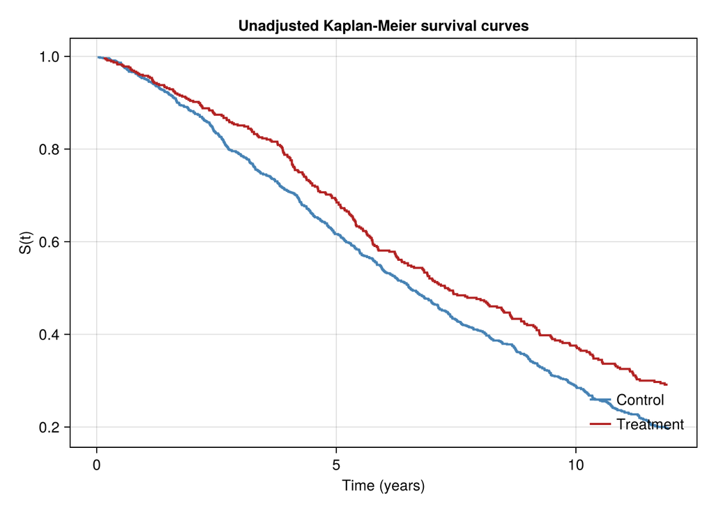

```julia
"""
    kaplan_meier(time, event)
Compute Kaplan-Meier survival estimates at the unique event times.
Returns (times, survival).
"""
function kaplan_meier(time, event)
    df_sort = sort(DataFrame(t = time, d = event), :t)
    event_times = unique(df_sort.t[df_sort.d .== 1])
    survival = Float64[]
    s = 1.0
    for t in event_times
        n_at_risk = sum(df_sort.t .>= t)
        n_events  = sum((df_sort.t .== t) .& (df_sort.d .== 1))
        s *= 1 - n_events / n_at_risk
        push!(survival, s)
    end
    return event_times, survival
end

t_trt, s_trt = kaplan_meier(df.time[df.trt .== 1], df.event[df.trt .== 1])
t_ctl, s_ctl = kaplan_meier(df.time[df.trt .== 0], df.event[df.trt .== 0])

fig = Figure(size = (700, 400))
ax = Axis(fig[1, 1], xlabel = "Time (years)", ylabel = "S(t)",
          title = "Unadjusted Kaplan-Meier survival curves")
stairs!(ax, t_ctl, s_ctl, color = :steelblue, linewidth = 2,
        label = "Control")
stairs!(ax, t_trt, s_trt, color = :firebrick, linewidth = 2,
        label = "Treatment")
axislegend(ax, position = :rb, framevisible = false)
fig
```

The unadjusted KM curves are descriptive. They include both the treatment effect and baseline imbalance.

## 22.4 IPW-adjusted survival

To adjust for confounding, weight observations by the inverse propensity score before computing KM. These weights adjust for treatment assignment only. They do nothing about censoring, so the weighted KM curve is valid only if censoring is independent of the event time within each treatment arm. That holds here by construction: the simulated censoring is random dropout plus an administrative end of follow-up at 12 years. If censoring depended on prognosis, we would also need inverse-probability-of-censoring weights. The weights are capped at their 99th percentile, a choice that trades a little bias for less variance and that should be checked for sensitivity.

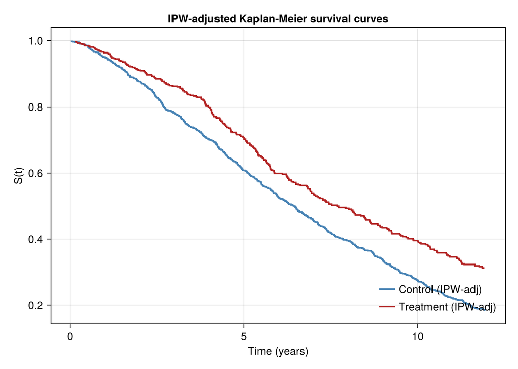

```julia
ps_fit = glm(@formula(trt ~ age + sex), df, Binomial(), LogitLink())
df.ps  = predict(ps_fit)
df.ipw = ifelse.(df.trt .== 1, 1 ./ df.ps, 1 ./ (1 .- df.ps))
df.ipw .= min.(df.ipw, quantile(df.ipw, 0.99))

"""
    weighted_kaplan_meier(time, event, weights)
KM estimate with sample weights — used for IPW-adjusted survival.
"""
function weighted_kaplan_meier(time, event, weights)
    df_sort = sort(DataFrame(t = time, d = event, w = weights), :t)
    event_times = unique(df_sort.t[df_sort.d .== 1])
    survival = Float64[]
    s = 1.0
    for t in event_times
        w_at_risk = sum(df_sort.w[df_sort.t .>= t])
        w_events  = sum(df_sort.w[(df_sort.t .== t) .& (df_sort.d .== 1)])
        s *= 1 - w_events / w_at_risk
        push!(survival, s)
    end
    return event_times, survival
end

t_trt_w, s_trt_w = weighted_kaplan_meier(df.time[df.trt .== 1],
                                          df.event[df.trt .== 1],
                                          df.ipw[df.trt .== 1])
t_ctl_w, s_ctl_w = weighted_kaplan_meier(df.time[df.trt .== 0],
                                          df.event[df.trt .== 0],
                                          df.ipw[df.trt .== 0])

fig2 = Figure(size = (700, 400))
ax2 = Axis(fig2[1, 1], xlabel = "Time (years)", ylabel = "S(t)",
           title = "IPW-adjusted Kaplan-Meier survival curves")
stairs!(ax2, t_ctl_w, s_ctl_w, color = :steelblue, linewidth = 2,
        label = "Control (IPW-adj)")
stairs!(ax2, t_trt_w, s_trt_w, color = :firebrick, linewidth = 2,
        label = "Treatment (IPW-adj)")
axislegend(ax2, position = :rb, framevisible = false)
fig2
```

The IPW-adjusted curves remove the age and sex imbalance that is in the propensity score model.

## 22.5 Restricted Mean Survival Time

The **RMST** up to time $\tau$ is

$$\text{RMST}(\tau) = E[\min(T, \tau)] = \int_0^\tau S(t) \, dt.
\tag{22.2}$$

The contrast $\Delta_{\text{RMST}}(\tau)=\text{RMST}_1(\tau)-\text{RMST}_0(\tau)$ is interpretable as years gained up to $\tau$. It does not require proportional hazards.

Because the KM curve is a step function, its integral is computed exactly by a left rectangle sum (width times the survival value at the left endpoint of each segment):

```julia
function rmst(times, survival, tau)
    # Add time 0 and the truncation point, with appropriate S values
    t_vec = [0.0; times; tau]
    s_vec = [1.0; survival; survival[end]]
    # Restrict to times ≤ tau
    keep = t_vec .<= tau
    t_use = t_vec[keep]
    s_use = s_vec[keep]
    # Add the tau endpoint, unless it's already the last element (t_vec was
    # constructed with tau appended, so `keep` already retains it -- pushing
    # again would duplicate it and create a zero-width trailing interval).
    if t_use[end] != tau
        push!(t_use, tau)
        push!(s_use, s_use[end])
    end
    # Exact integral of the KM step function: width × left-height
    sum(diff(t_use) .* s_use[1:end-1])
end

τ = 5.0
rmst_trt_unadj = rmst(t_trt, s_trt, τ)
rmst_ctl_unadj = rmst(t_ctl, s_ctl, τ)
rmst_trt_adj   = rmst(t_trt_w, s_trt_w, τ)
rmst_ctl_adj   = rmst(t_ctl_w, s_ctl_w, τ)

@printf("Unadjusted RMST(τ=5):\n")
@printf("  Treatment: %.3f years    Control: %.3f years    Diff: %.3f\n",
        rmst_trt_unadj, rmst_ctl_unadj, rmst_trt_unadj - rmst_ctl_unadj)
@printf("IPW-adjusted RMST(τ=5):\n")
@printf("  Treatment: %.3f years    Control: %.3f years    Diff: %.3f\n",
        rmst_trt_adj, rmst_ctl_adj, rmst_trt_adj - rmst_ctl_adj)
```

```
Unadjusted RMST(τ=5):
  Treatment: 4.351 years    Control: 4.147 years    Diff: 0.203
IPW-adjusted RMST(τ=5):
  Treatment: 4.397 years    Control: 4.122 years    Diff: 0.275
```

The IPW-adjusted RMST difference is the adjusted years-gained estimate up to 5 years.

## 22.6 Cox proportional hazards (regression adjustment)

Julia’s survival-regression tools are less mature than R’s `survival::coxph`. In Julia, the choices are:

- Use `Survival.jl` for basic Cox PH (limited adjustment capabilities).
- Use a parametric Weibull/exponential model via `Distributions` and `Optim` directly.
- Call out to R for serious survival modelling.

For applied work where the Cox model with covariate adjustment is the target, R remains the practical choice. See the [companion R chapter](https://xiangao.github.io/causal_econometrics_guide/survival-causal.html) for the full Cox + IPCW + doubly-robust workflow.

## 22.7 Doubly-robust survival estimation

R’s `riskRegression::ate` combines a Cox outcome model with a propensity score and censoring model. Julia does not currently have an equivalent.

For now, the practical Julia workflow is:

1. **Description**: unadjusted KM curves (this chapter).
2. **Adjusted survival**: IPW-weighted KM (this chapter).
3. **Causal contrasts**: RMST differences from the IPW-adjusted KM (this chapter).
4. **Cox HR with adjustment + doubly-robust estimators**: call out to R via `RCall.jl` or use the [R companion chapter](https://xiangao.github.io/causal_econometrics_guide/survival-causal.html).

## 22.8 When to use these methods

Use these methods when:

1. The outcome is time-to-event with censoring.
2. The treatment effect on survival probabilities or years-of-life is the causal question.

For non-censored outcomes, the standard Estimation and Heterogeneous Effects methods are sufficient.

## 22.9 Summary

- Survival outcomes require methods that handle censoring.
- Kaplan-Meier estimates the survival curve nonparametrically.
- IPW-adjusted KM handles baseline confounding through weights.
- RMST differences are often the clearest causal summary.
- For Cox regression and doubly robust survival estimators, use R for now.

Hernán, Miguel A. 2010. “The Hazards of Hazard Ratios.” *Epidemiology* 21 (1): 13–15.